# Ryzyko kredytowe portfela

CreditMetrics · migracje ratingów, VaR, ES i analiza wrażliwości

Autor

Krzysztof Włosek

# Pytanie analityczne

Jak duża może być roczna strata portfela pięciu hipotetycznych ekspozycji kredytowych oraz które założenia i pozycje odpowiadają za jego ryzyko? Portfel ma nominał **100,00 mln USD**. Ekspozycje to nowe, pięcioletnie obligacje zerokuponowe w modelu; nie są zidentyfikowanymi, rzeczywiście zawartymi transakcjami.

Strata oznacza różnicę między wartością portfela po roku **bez migracji ratingów** a jego wartością w danym scenariuszu. Nie jest stratą względem ceny początkowej ani jednodniową stratą portfela akcji. Ujemne straty są zachowanymi zyskami z poprawy wyceny.

VaR 99,0%

5,90

mln USD

ES 99,0%

8,07

mln USD

Dokładna oczekiwana strata

0,47

mln USD

**Wspólna data rynkowa:** 2026-10-09. **Żądana data graniczna analizy:** 2026-10-15. **Scenariusze na wariant:** 1 000 000. Data danych może poprzedzać datę graniczną z powodu harmonogramu publikacji krzywej Fed. Raport odtwarza wybrany zapis wyników i nie pobiera nowych notowań.

**WażneStatus walidacji**

Wyniki symulacyjne i tożsamości wyceny są sprawdzane na zapisanych wejściach. **Trafność VaR na rzeczywistych przyszłych stratach nie wynika z tych kontroli.** Status osobnego backtestu przedstawiono w sekcji „Walidacja VaR”.

# Dane i założenia

Tabela 1: Skład portfela i daty dowodów ratingowych.

| Emitent | Rating S&P | Grupa modelu | Nominał [mln USD] | Udział [%] | Data źródła ratingu |
| --- | --- | --- | --- | --- | --- |
| INTC | BBB | BBB | 30,00 | 30,00 | 2026-04-27 |
| AMZN | AA | AA | 20,00 | 20,00 | 2026-03-10 |
| NVDA | AA | AA | 17,00 | 17,00 | 2026-08-18 |
| NTAP | BBB+ | BBB | 15,00 | 15,00 | 2025-03-12 |
| VTOL | B+ | B | 18,00 | 18,00 | 2026-01-13 |

Ratingi są ręcznie przeglądanymi danymi wejściowymi, a daty źródeł nie są datami nowych działań ratingowych. Starsze potwierdzenie nie stanowi gwarancji bieżącego statusu. Rejestr zachowuje źródła i odrębną datę przeglądu. W szczególności dokument dla NetApp może być znacznie starszy niż data analizy.

Krzywa Treasury pochodzi z estymacji GSW Fed, a spready ratingowe z indeksów ICE BofA udostępnianych przez FRED. Indeksowy OAS traktujemy jako przybliżony, płaski spread ciągły, a nie krzywą zerokuponową konkretnego emitenta. Roczna macierz migracji jest historycznym oszacowaniem S&P dla korporacji globalnych. Nie jest indywidualną prognozą emitenta ani macierzą neutralną względem ryzyka. Polityka NR: **condition_on_observed**.

Po roku pozostają cztery lata do zapadalności. Dla przeżywających pozycji wykorzystujemy deterministyczną stopę forward Treasury i spread stanu docelowego. W default odzysk wynosi **40%** nominału, płatne na koniec horyzontu. To jawne założenie, nie oszacowana tutaj bieżąca stopa odzysku. Model opiera się na logice migracyjnej CreditMetrics (Gupton et al. 1997).

## Zależność emitentów

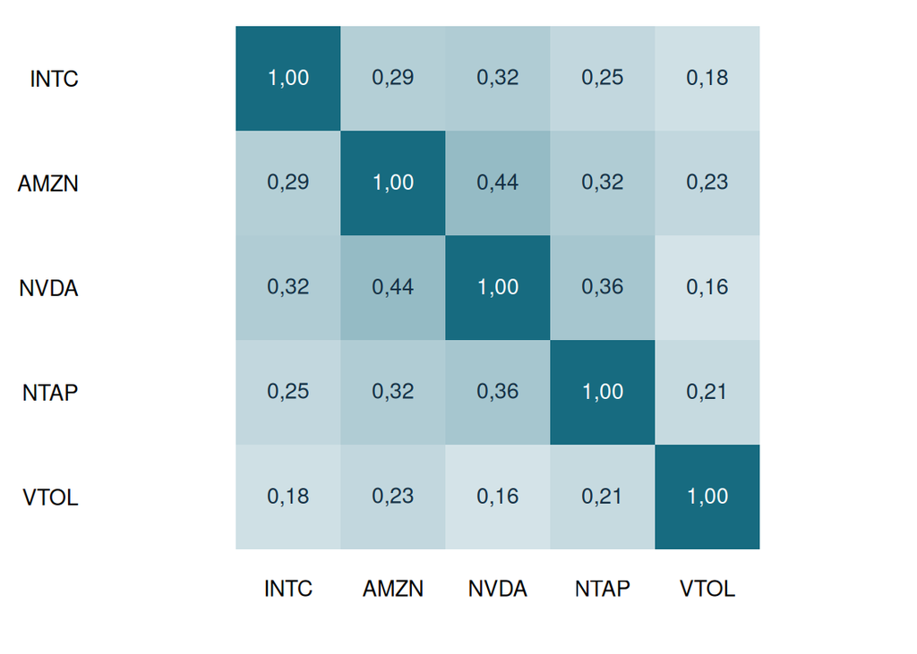

Rysunek 1: Korelacje wspólnych dziennych zwrotów Adjusted. To przybliżenie zależności latentnej, a nie korelacja niewypłacalności.

Korelacje oszacowano na jednej kompletnej próbie, z końcem w dniu wyceny. Braki nie są interpolowane, a duże zwroty są oznaczane do przeglądu i zachowane. Niepewność estymacji korelacji i jakość korekt dostawcy nie są ujęte w błędzie Monte Carlo. Przedziały symulacyjne nie zastępują kontroli źródeł danych.

# Bazowy rozkład strat

Tabela 2: VaR i Expected Shortfall: straty w mln USD.

| Poziom [%] | VaR | ES | VaR: dolny kraniec MC | VaR: górny kraniec MC | Przybliżony SE dla ES |
| --- | --- | --- | --- | --- | --- |
| 95,0 | 4,15 | 5,91 | 4,14 | 4,15 | 0,011 |
| 99,0 | 5,90 | 8,07 | 5,90 | 5,90 | 0,035 |
| 99,9 | 11,62 | 14,23 | 11,56 | 11,62 | 0,115 |

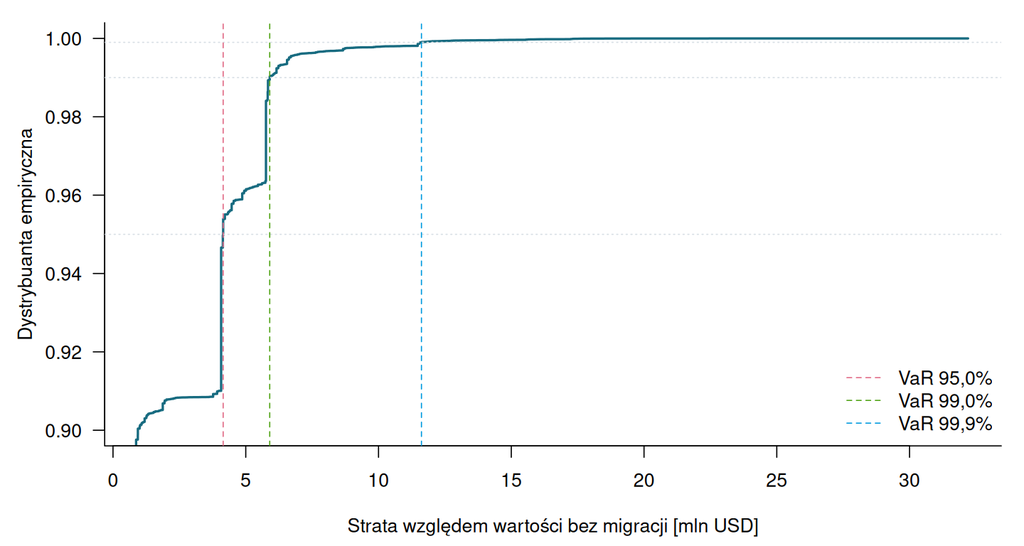

Rysunek 2: Górny fragment dystrybuanty strat z symulacji. Schodki zachowują masy dyskretne; wykres nie przedstawia rzeczywistych kolejnych okresów.

VaR jest odwrotnością dystrybuanty empirycznej (`quantile(type = 1)`). ES obejmuje dokładnie zadaną masę najgorszego ogona, w razie potrzeby wykorzystując część scenariuszy równych VaR. Średnia samych strat **ściśle większych** od VaR nie jest ogólnie poprawną definicją ES dla takiego rozkładu (Acerbi i Tasche 2002).

Przedziały VaR wynikają z rang dwumianowych. Błąd ES jest przybliżony; normalne przedziały ES są pomijane, gdy kwantyl nie jest rozstrzygnięty przez przedział rang. Te miary opisują wyłącznie skończoną liczbę losowań przy ustalonych danych i modelu. Nie obejmują ryzyka parametrów ani specyfikacji.

## Kto tworzy ryzyko ogona?

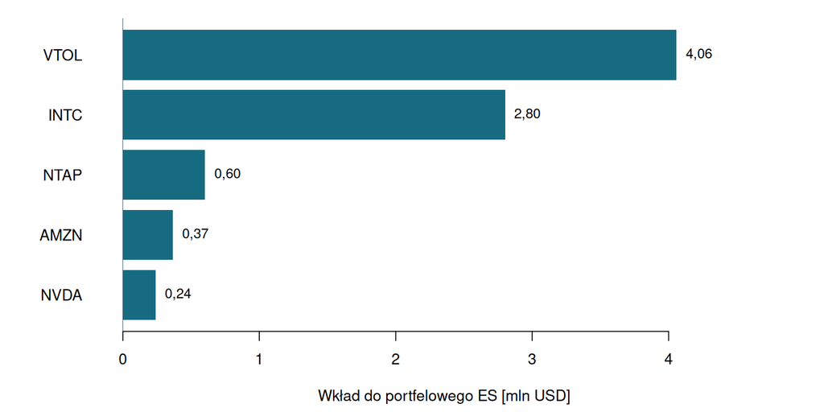

Rysunek 3: Wkłady emitentów do ES 99,0%. Ich suma jest równa portfelowemu ES.

Wkłady wykorzystują te same wagi portfelowego ogona, także na granicy VaR. Nie są niezależnie liczonymi ES poszczególnych obligacji. Pozwala to odróżnić udział w nominale od udziału w stratach najgorszych scenariuszy.

# Analiza wrażliwości

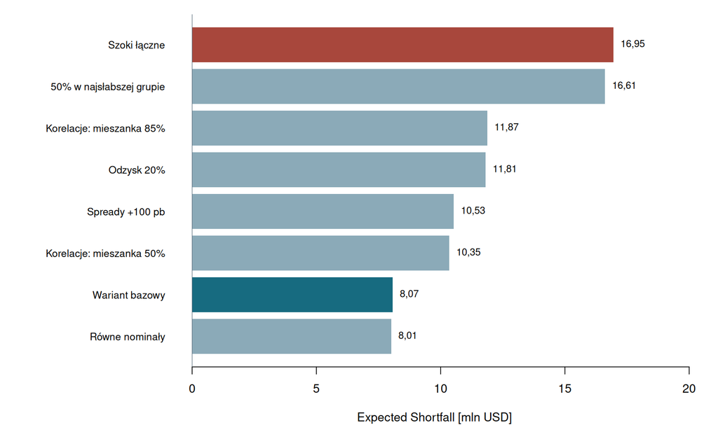

Rysunek 4: Porównanie ES 99,0% przy wspólnym budżecie nominału. Rozmiary szoków są przyjętymi założeniami.

Tabela 3: Ryzyko i koncentracja przy wybranym poziomie ufności.

| Wariant | VaR | ES | Zmiana ES [%] | Oczekiwana strata | HHI nominału |
| --- | --- | --- | --- | --- | --- |
| Wariant bazowy | 5,90 | 8,07 | 0,0 | 0,47 | 0,214 |
| Korelacje: mieszanka 50% | 6,70 | 10,35 | 28,2 | 0,47 | 0,214 |
| Korelacje: mieszanka 85% | 7,26 | 11,87 | 47,1 | 0,47 | 0,214 |
| Spready +100 pb | 8,43 | 10,53 | 30,5 | 3,48 | 0,214 |
| Odzysk 20% | 9,44 | 11,81 | 46,3 | 0,60 | 0,214 |
| Szoki łączne | 12,80 | 16,95 | 110,1 | 3,61 | 0,214 |
| Równe nominały | 6,55 | 8,01 | -0,8 | 0,50 | 0,200 |
| 50% w najsłabszej grupie | 16,05 | 16,61 | 105,9 | 1,10 | 0,317 |

Spready są szokowane dopiero w wycenie na koniec roku. Bazowy punkt odniesienia pozostaje stały dla danej alokacji, aby zachować stratę z przeceny także bez migracji ratingu. Zmiana odzysku wpływa na default, a mieszanka korelacji przesuwa macierz w stronę macierzy samych jedynek, zachowując PSD. Macierz migracji pozostaje niezmieniona.

Scenariusze wykorzystują wspólne innowacje losowe. Różnice mają sparowane błędy Monte Carlo; redukcja wariancji nie jest gwarantowana przy zmianie faktora korelacji. Przedział różnicy ES wymaga rozstrzygnięcia obu kwantyli. Wariant łączny jest analizą wrażliwości, nie skalibrowaną prognozą recesji ani scenariuszem o oszacowanym prawdopodobieństwie.

Najwyższy ES przy poziomie **99,0%** występuje w wariancie **Szoki łączne** i wynosi **16,95 mln USD**.

Zmiana na równe nominały zmienia również skład ryzyka ratingowego. W tym zapisie ES rośnie na części poziomów ufności, a maleje na innych. Niższy HHI nie oznacza jednolitej poprawy ryzyka.

# Kontrole obliczeń

Tabela 4: Dokładna i symulowana średnia straty. Z mierzy różnicę w jednostkach błędu Monte Carlo.

| Wariant | Średnia dokładna | Średnia MC | SE średniej | Z | W granicach 6 SE |
| --- | --- | --- | --- | --- | --- |
| Wariant bazowy | 0,4670 | 0,4675 | 0,0016 | 0,34 | tak |
| Korelacje: mieszanka 50% | 0,4670 | 0,4684 | 0,0017 | 0,82 | tak |
| Korelacje: mieszanka 85% | 0,4670 | 0,4674 | 0,0019 | 0,23 | tak |
| Spready +100 pb | 3,4828 | 3,4832 | 0,0015 | 0,30 | tak |
| Odzysk 20% | 0,5991 | 0,6006 | 0,0021 | 0,72 | tak |
| Szoki łączne | 3,6149 | 3,6167 | 0,0022 | 0,79 | tak |
| Równe nominały | 0,5023 | 0,5029 | 0,0017 | 0,33 | tak |
| 50% w najsłabszej grupie | 1,0982 | 1,0985 | 0,0039 | 0,09 | tak |

Tabele raportu są ponownie liczone z zapisanych stanów docelowych i cen warunkowych. Sprawdzana jest zgodność strat, punktów odniesienia i sumy wkładów ES. Nie korzystają z ręcznie przepisanych wyników. Osobne testy oprogramowania obejmują przykłady o znanym wyniku, granice prawdopodobieństw i odtwarzalność. Kontrole te nie są testami trafności prognoz na przyszłych danych.

# Walidacja VaR

**Backtest na rzeczywistych wynikach: niewykonany.**

Nie dostarczono szeregu prognoz VaR i późniejszych, porównywalnych strat. Brak wyników testu nie jest pozytywną oceną modelu.

## Test wartości rzeczywistych

Dla prognozy wyznaczonej wyłącznie z wcześniejszego okna estymacji sprawdzamy w następnym okresie, czy **zrealizowana strata jest większa od VaR**. Przy niezależnych wyjątkach i stałej docelowej częstości `p₀ = 1 − α` ich liczba `M` w `N` okresach ma rozkład dwumianowy. Dla zaobserwowanego `m` liczymy:

$$p_{dolny}=P(M\leq m),\qquad p_{górny}=P(M\geq m).$$

W opisanej przez autora projektu regule oba prawdopodobieństwa muszą być **większe od 5%**. Są to dwa testy jednostronne po 5%, więc łączny poziom odrzucenia wynosi najwyżej 10%. Wariant z 2,5% na ogon daje łącznie najwyżej 5%. Obie konwencje są implementowane; nie są utożsamiane z tą samą regułą.

**Pokaż kod**

```r
p_lower <- pbinom(m, N, 1 - alpha)
p_upper <- pbinom(m - 1, N, 1 - alpha, lower.tail = FALSE)
not_rejected <- p_lower > 0.05 && p_upper > 0.05
```

## Test Kupca i ograniczenia interpretacji

Test Kupca porównuje częstość przekroczeń z zadanym prawdopodobieństwem przez iloraz wiarygodności, z asymptotycznym odniesieniem do rozkładu chi-kwadrat z jednym stopniem swobody. Nie testuje samodzielnie niezależności wyjątków ani wielkości strat po przekroczeniu VaR. Brak odrzucenia, zwłaszcza przy małej oczekiwanej liczbie wyjątków, nie potwierdza poprawności modelu (Kupiec 1995; Cassidy i Gizycki 1997).

W modelu migracyjnym rozkład jest dyskretny. Dla poprawnego kwantyla częstość **ścisłych** przekroczeń może być mniejsza niż `1 − α` ze względu na masę równą VaR. Test równości z nominalną częstością wymaga więc dodatkowej interpretacji; odrzucenie z powodu zbyt małej liczby wyjątków może oznaczać konserwatywny kwantyl. Kod zachowuje liczbę remisów i obie strony testu.

Do empirycznego badania tego projektu potrzebne są historyczne prognozy rocznego VaR, odtwarzalne dane dostępne w chwili prognozy oraz późniejsze roczne straty tych samych ekspozycji i względem tego samego benchmarku. Dzienne zwroty akcji służą tutaj tylko do kalibracji zależności i nie są rzeczywistą stratą modelowanych obligacji. Nakładające się roczne okresy nie tworzą niezależnych prób dwumianowych. Samo zastosowanie kroczącego okna estymacji nie rozwiązuje tego problemu.

Przy 20 niezależnych rocznych okresach i VaR 99% oczekiwana liczba wyjątków wynosi jedynie 0,2. To przykład ograniczonej informacji testowej, nie wynik backtestu tego portfela. Dalsza walidacja wymaga historii ratingów, krzywych, odzysków i ekspozycji oraz uzgodnionej metody rzeczywistej lub zastępczej rewaluacji. Testy niezależności i odrębna walidacja ES pozostają dalszym zadaniem.

# Odtwarzalność i granice wniosków

Wyniki zależą od ręcznego rejestru ratingów, długookresowej macierzy migracji, proxy korelacji akcji, stałego odzysku i uproszczonych spreadów. Model nie obejmuje losowych przyszłych stóp, płynności, momentu default, opóźnienia odzysku ani kryzysowej zmiany wszystkich parametrów. Obecna wersja pokazuje odtwarzalną analizę modelową i jej ograniczenia; nie stanowi zwalidowanego systemu prognoz ani rekomendacji inwestycyjnej.

## Literatura

Acerbi, Carlo, i Dirk Tasche. 2002. „On the coherence of expected shortfall”. *Journal of Banking and Finance* 26: 1487–503. https://arxiv.org/abs/cond-mat/0104295.

Cassidy, Colleen, i Marianne Gizycki. 1997. *Measuring Traded Market Risk: Value-at-Risk and Backtesting Techniques*. Nr 9708. Research Discussion Paper. Reserve Bank of Australia. https://www.rba.gov.au/publications/rdp/1997/9708/backtesting.html.

Gupton, Greg M., Christopher C. Finger, i Mickey Bhatia. 1997. *CreditMetrics: Technical Document*. J. P. Morgan. https://www.msci.com/documents/10199/93396227-d449-4229-9143-24a94dab122f.

Kupiec, Paul H. 1995. *Techniques for Verifying the Accuracy of Risk Measurement Models*. Nr. 95-24. Finance i Economics Discussion Series. Board of Governors of the Federal Reserve System. https://fraser.stlouisfed.org/title/1491/item/717921.